# Houseprice

House price EDA on the basis of IOWA 1 . Descriptive stats + marginal distribution of the dependent variable (SalePrice)

```python
import pandas as pd
import seaborn as sns
import matplotlib.pyplot as plt
import numpy as np

# Comment this if the data visualisations doesn't work on your side
%matplotlib inline
```

```python
train_file_path = "/Users/maneshss/Desktop/Study/Project/Mangithub/Mangithub/MachineLearning/Houseprice/Data/train.csv"
dataset_df = pd.read_csv(train_file_path)
print("Full train dataset shape is {}".format(dataset_df.shape))
```

```
Full train dataset shape is (1460, 81)
```

```python
dataset_df.head(3)
```

|  | Id | MSSubClass | MSZoning | LotFrontage | LotArea | Street | Alley | LotShape | LandContour | Utilities | ... | PoolArea | PoolQC | Fence | MiscFeature | MiscVal | MoSold | YrSold | SaleType | SaleCondition | SalePrice |
| --- | --- | --- | --- | --- | --- | --- | --- | --- | --- | --- | --- | --- | --- | --- | --- | --- | --- | --- | --- | --- | --- |
| 0 | 1 | 60 | RL | 65.0 | 8450 | Pave | NaN | Reg | Lvl | AllPub | ... | 0 | NaN | NaN | NaN | 0 | 2 | 2008 | WD | Normal | 208500 |
| 1 | 2 | 20 | RL | 80.0 | 9600 | Pave | NaN | Reg | Lvl | AllPub | ... | 0 | NaN | NaN | NaN | 0 | 5 | 2007 | WD | Normal | 181500 |
| 2 | 3 | 60 | RL | 68.0 | 11250 | Pave | NaN | IR1 | Lvl | AllPub | ... | 0 | NaN | NaN | NaN | 0 | 9 | 2008 | WD | Normal | 223500 |

3 rows × 81 columns

The data set has 81 column and 1460 rows .This quesry gives us and understanding records and what are the number of columns .Which columns has to be taken for comparison

```python
# Query to display columns and it content to understand data
dataset_df = dataset_df.drop('Id', axis=1)
dataset_df.head(3)
```

|  | MSSubClass | MSZoning | LotFrontage | LotArea | Street | Alley | LotShape | LandContour | Utilities | LotConfig | ... | PoolArea | PoolQC | Fence | MiscFeature | MiscVal | MoSold | YrSold | SaleType | SaleCondition | SalePrice |
| --- | --- | --- | --- | --- | --- | --- | --- | --- | --- | --- | --- | --- | --- | --- | --- | --- | --- | --- | --- | --- | --- |
| 0 | 60 | RL | 65.0 | 8450 | Pave | NaN | Reg | Lvl | AllPub | Inside | ... | 0 | NaN | NaN | NaN | 0 | 2 | 2008 | WD | Normal | 208500 |
| 1 | 20 | RL | 80.0 | 9600 | Pave | NaN | Reg | Lvl | AllPub | FR2 | ... | 0 | NaN | NaN | NaN | 0 | 5 | 2007 | WD | Normal | 181500 |
| 2 | 60 | RL | 68.0 | 11250 | Pave | NaN | IR1 | Lvl | AllPub | Inside | ... | 0 | NaN | NaN | NaN | 0 | 9 | 2008 | WD | Normal | 223500 |

3 rows × 80 columns

we will drop the ID column as it is not valuable for doing any data analysis

```python
dataset_df.info()
```

```
<class 'pandas.core.frame.DataFrame'>
RangeIndex: 1460 entries, 0 to 1459
Data columns (total 80 columns):
 #   Column         Non-Null Count  Dtype
---  ------         --------------  -----
 0   MSSubClass     1460 non-null   int64
 1   MSZoning       1460 non-null   object
 2   LotFrontage    1201 non-null   float64
 3   LotArea        1460 non-null   int64
 4   Street         1460 non-null   object
 5   Alley          91 non-null     object
 6   LotShape       1460 non-null   object
 7   LandContour    1460 non-null   object
 8   Utilities      1460 non-null   object
 9   LotConfig      1460 non-null   object
```

[output cut: 72 more lines]

This gives the number of columns and their description with number of rows .This also will gives us an idea what are the missing values and in which column it is more Now let us look the how the price distribution is their currently

```
count      1460.000000
mean     180921.195890
std       79442.502883
min       34900.000000
25%      129975.000000
50%      163000.000000
75%      214000.000000
max      755000.000000
Name: SalePrice, dtype: float64
```

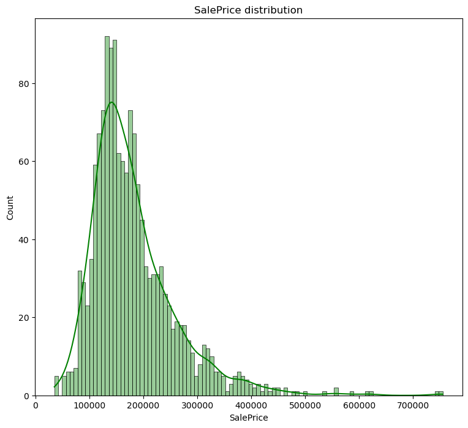

```python
print(dataset_df['SalePrice'].describe())
plt.figure(figsize=(9, 8))
ax = sns.histplot(dataset_df["SalePrice"], bins=100, color="g", alpha=0.4,kde=True)  # add kde=True if you want
ax.set_title("SalePrice distribution")
plt.show()
```

Interpretation of SalePrice Descriptive Statistics

The summary statistics describe the distribution of the dependent variable SalePrice for 1,460 observations. SalePrice has a mean of 180,921 and a median (50th percentile) of 163,000. Since the mean is higher than the median, the distribution appears to be right-skewed, suggesting that a smaller number of high-priced homes pull the average upward.

The standard deviation is 79,442, indicating substantial variability in house prices. The minimum SalePrice is 34,900 and the maximum is 755,000, showing a very wide range and confirming the presence of high-end outliers. The 25th percentile is 129,975 and the 75th percentile is 214,000, meaning the middle 50 percent of homes are priced between 129,975 and 214,000. Overall, SalePrice is widely dispersed and likely right-skewed with extreme upper values, which is important to consider for downstream modeling and potential transformations.

2 . Investigate missing data and outliers. Let us check whether their are missing values and what is the impact

```python
features_with_na = [col for col in dataset_df.columns if dataset_df[col].isnull().sum() > 1]

for col in features_with_na:
    print(col, np.round(dataset_df[col].isnull().mean(), 4), "% missing values")
```

```
LotFrontage 0.1774 % missing values
Alley 0.9377 % missing values
MasVnrType 0.5973 % missing values
MasVnrArea 0.0055 % missing values
BsmtQual 0.0253 % missing values
BsmtCond 0.0253 % missing values
BsmtExposure 0.026 % missing values
BsmtFinType1 0.0253 % missing values
BsmtFinType2 0.026 % missing values
FireplaceQu 0.4726 % missing values
GarageType 0.0555 % missing values
GarageYrBlt 0.0555 % missing values
GarageFinish 0.0555 % missing values
GarageQual 0.0555 % missing values
GarageCond 0.0555 % missing values
PoolQC 0.9952 % missing values
Fence 0.8075 % missing values
MiscFeature 0.963 % missing values
```

Missing Data Summary

The dataset contains several variables with missing values, ranging from very small fractions to nearly complete missingness. The most extreme cases are PoolQC (99.52 percent missing), MiscFeature (96.30 percent missing), and Alley (93.77 percent missing), indicating that these features are not recorded for the vast majority of homes. This pattern likely reflects true absence of the feature (e.g., most homes do not have a pool or alley access) rather than random missingness.

Fence also has substantial missingness (80.75 percent), and FireplaceQu shows moderate missingness (47.26 percent), suggesting these amenities are present only for a subset of properties. Several basement-related variables (BsmtQual, BsmtCond, BsmtExposure, BsmtFinType1, BsmtFinType2) have low missingness (around 2.5 to 2.6 percent), and garage-related variables (GarageType, GarageYrBlt, GarageFinish, GarageQual, GarageCond) have modest missingness (about 5.55 percent). LotFrontage has 17.74 percent missing values, which is notable and may require careful imputation because it is a continuous measurement often related to property size and location.

Overall, the missingness is concentrated in a few amenity-related variables with very high rates, while most other variables have relatively low levels of missing data. These patterns suggest that different strategies may be appropriate, such as treating high-missingness amenity variables as “not present” categories, and using imputation methods for continuous variables like LotFrontage.

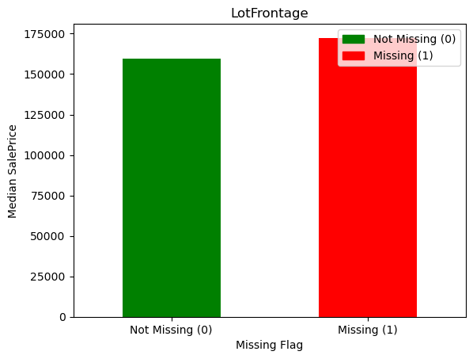

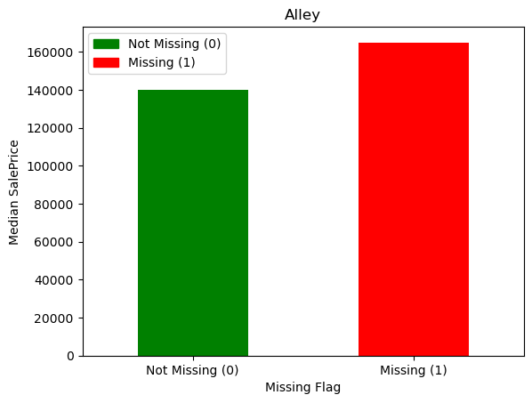

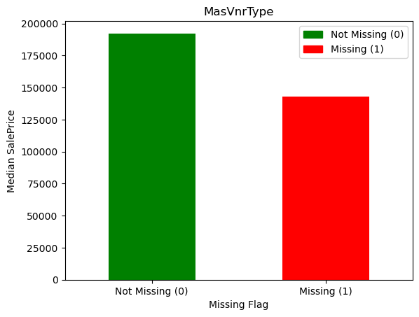

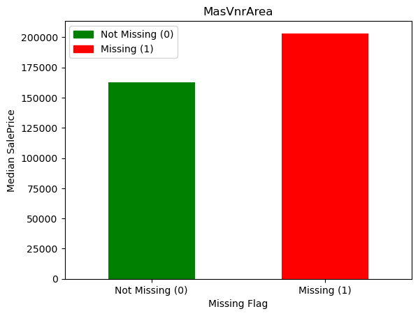

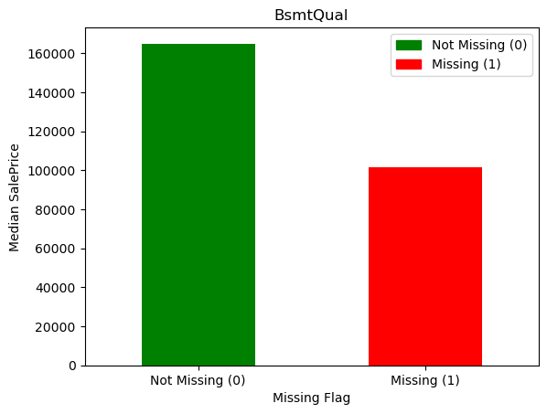

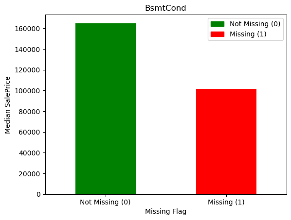

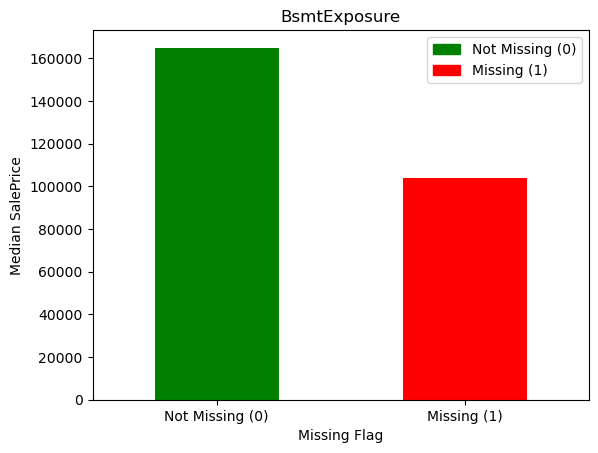

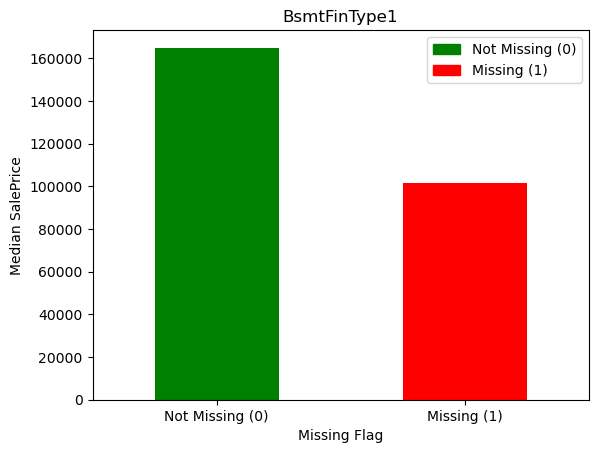

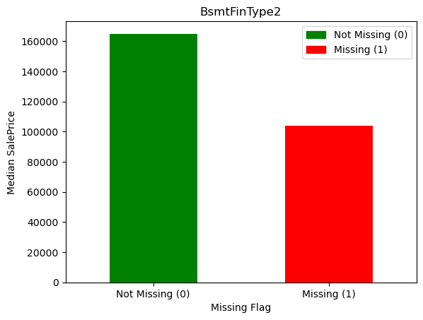

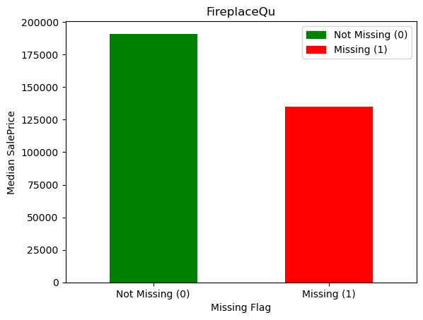

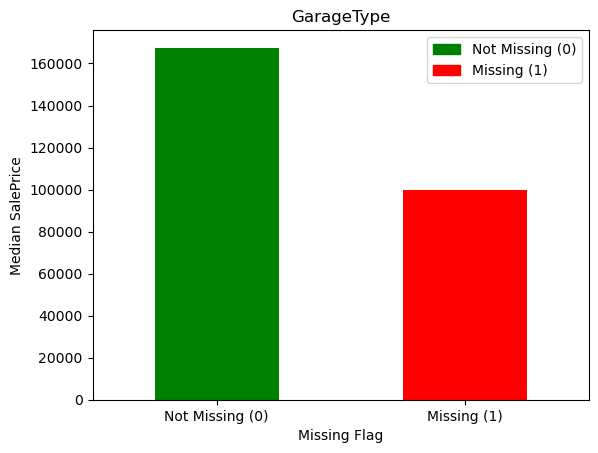

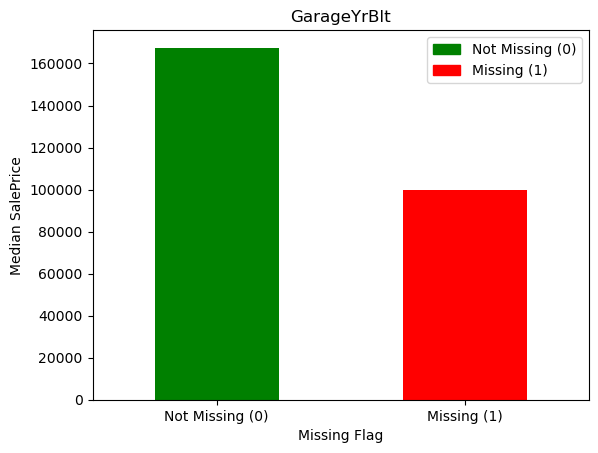

[6 more figures not shown]

```python
import numpy as np
import matplotlib.pyplot as plt
from matplotlib.patches import Patch

for feature in features_with_na:
    data = dataset_df.copy()

    # 1 if missing, 0 otherwise
    data[feature] = np.where(data[feature].isnull(), 1, 0)

    # median SalePrice by missing flag (force order 0 then 1)
    medians = data.groupby(feature)["SalePrice"].median().reindex([0, 1])

    ax = medians.plot(kind="bar", color=["green", "red"])
    ax.set_title(feature)
    ax.set_xlabel("Missing Flag")
    ax.set_ylabel("Median SalePrice")
    ax.set_xticklabels(["Not Missing (0)", "Missing (1)"], rotation=0)

    # legend
    ax.legend(handles=[
        Patch(color="green", label="Not Missing (0)"),
        Patch(color="red", label="Missing (1)")
    ])

    plt.show()
```

Now let us look at the numeric variable and their distribution

```python
list(set(dataset_df.dtypes.tolist()))
```

```
[dtype('O'), dtype('int64'), dtype('float64')]
```

```python
df_num = dataset_df.select_dtypes(include = ['float64', 'int64'])
df_num.head()
```

|  | MSSubClass | LotFrontage | LotArea | OverallQual | OverallCond | YearBuilt | YearRemodAdd | MasVnrArea | BsmtFinSF1 | BsmtFinSF2 | ... | WoodDeckSF | OpenPorchSF | EnclosedPorch | 3SsnPorch | ScreenPorch | PoolArea | MiscVal | MoSold | YrSold | SalePrice |
| --- | --- | --- | --- | --- | --- | --- | --- | --- | --- | --- | --- | --- | --- | --- | --- | --- | --- | --- | --- | --- | --- |
| 0 | 60 | 65.0 | 8450 | 7 | 5 | 2003 | 2003 | 196.0 | 706 | 0 | ... | 0 | 61 | 0 | 0 | 0 | 0 | 0 | 2 | 2008 | 208500 |
| 1 | 20 | 80.0 | 9600 | 6 | 8 | 1976 | 1976 | 0.0 | 978 | 0 | ... | 298 | 0 | 0 | 0 | 0 | 0 | 0 | 5 | 2007 | 181500 |
| 2 | 60 | 68.0 | 11250 | 7 | 5 | 2001 | 2002 | 162.0 | 486 | 0 | ... | 0 | 42 | 0 | 0 | 0 | 0 | 0 | 9 | 2008 | 223500 |
| 3 | 70 | 60.0 | 9550 | 7 | 5 | 1915 | 1970 | 0.0 | 216 | 0 | ... | 0 | 35 | 272 | 0 | 0 | 0 | 0 | 2 | 2006 | 140000 |
| 4 | 60 | 84.0 | 14260 | 8 | 5 | 2000 | 2000 | 350.0 | 655 | 0 | ... | 192 | 84 | 0 | 0 | 0 | 0 | 0 | 12 | 2008 | 250000 |

5 rows × 37 columns

```python
# list of numerical variables
numerical_features = [feature for feature in dataset_df.columns if dataset_df[feature].dtypes != 'O']

print('Number of numerical variables: ', len(numerical_features))

# visualise the numerical variables
dataset_df[numerical_features].head()
```

```
Number of numerical variables:  37
```

|  | MSSubClass | LotFrontage | LotArea | OverallQual | OverallCond | YearBuilt | YearRemodAdd | MasVnrArea | BsmtFinSF1 | BsmtFinSF2 | ... | WoodDeckSF | OpenPorchSF | EnclosedPorch | 3SsnPorch | ScreenPorch | PoolArea | MiscVal | MoSold | YrSold | SalePrice |
| --- | --- | --- | --- | --- | --- | --- | --- | --- | --- | --- | --- | --- | --- | --- | --- | --- | --- | --- | --- | --- | --- |
| 0 | 60 | 65.0 | 8450 | 7 | 5 | 2003 | 2003 | 196.0 | 706 | 0 | ... | 0 | 61 | 0 | 0 | 0 | 0 | 0 | 2 | 2008 | 208500 |
| 1 | 20 | 80.0 | 9600 | 6 | 8 | 1976 | 1976 | 0.0 | 978 | 0 | ... | 298 | 0 | 0 | 0 | 0 | 0 | 0 | 5 | 2007 | 181500 |
| 2 | 60 | 68.0 | 11250 | 7 | 5 | 2001 | 2002 | 162.0 | 486 | 0 | ... | 0 | 42 | 0 | 0 | 0 | 0 | 0 | 9 | 2008 | 223500 |
| 3 | 70 | 60.0 | 9550 | 7 | 5 | 1915 | 1970 | 0.0 | 216 | 0 | ... | 0 | 35 | 272 | 0 | 0 | 0 | 0 | 2 | 2006 | 140000 |
| 4 | 60 | 84.0 | 14260 | 8 | 5 | 2000 | 2000 | 350.0 | 655 | 0 | ... | 192 | 84 | 0 | 0 | 0 | 0 | 0 | 12 | 2008 | 250000 |

5 rows × 37 columns

Let us find out the Outliner

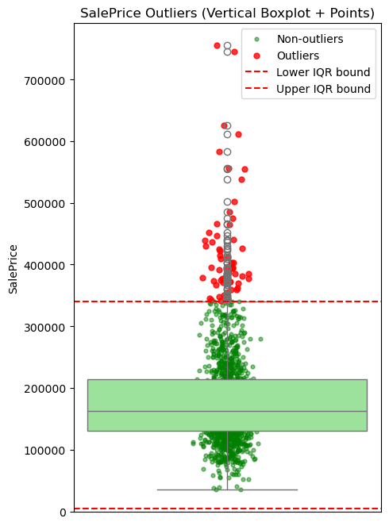

```python
# IQR bounds
Q1 = dataset_df["SalePrice"].quantile(0.25)
Q3 = dataset_df["SalePrice"].quantile(0.75)
IQR = Q3 - Q1
lower = Q1 - 1.5 * IQR
upper = Q3 + 1.5 * IQR

# split outliers vs non-outliers
y = dataset_df["SalePrice"].dropna()
mask_out = (y < lower) | (y > upper)

plt.figure(figsize=(5, 8))

# vertical boxplot
sns.boxplot(y=y, color="lightgreen")

# overlay points (x=0 line with small jitter)
x_non = np.random.normal(loc=0, scale=0.03, size=(~mask_out).sum())
x_out = np.random.normal(loc=0, scale=0.03, size=mask_out.sum())

plt.scatter(x_non, y[~mask_out], s=12, color="green", alpha=0.5, label="Non-outliers")
plt.scatter(x_out, y[mask_out], s=25, color="red", alpha=0.8, label="Outliers")

# IQR bounds
plt.axhline(lower, linestyle="--", color="red", label="Lower IQR bound")
plt.axhline(upper, linestyle="--", color="red", label="Upper IQR bound")

plt.title("SalePrice Outliers (Vertical Boxplot + Points)")
plt.ylabel("SalePrice")
plt.xticks([])  # hide x ticks since it's just jitter
plt.legend()
plt.show()
```

This figure combines a vertical boxplot of SalePrice with overlaid points to highlight outliers using the interquartile range (IQR) rule. The box represents the middle 50 percent of the data (Q1 to Q3), and the line inside the box is the median SalePrice. The dashed red horizontal lines indicate the IQR-based thresholds (lower bound and upper bound), where values below the lower bound or above the upper bound are flagged as outliers.

Most observations fall within the central range of the distribution (green points), concentrated around the median and within the whiskers of the boxplot. A noticeable set of points appear above the upper IQR bound (red points), indicating many high-price outliers. This confirms that SalePrice is right-skewed with a long upper tail, driven by a relatively small number of very expensive properties. There are few to no extreme low-price outliers, suggesting that the primary outlier concern is on the high end.

These outliers are important for modeling because they can disproportionately influence correlation estimates and regression coefficients. They should be inspected to determine whether they are valid high-value homes or potential data issues, and they may motivate using transformations such as log1p(SalePrice) or robust modeling approaches.

3 .Investigate at least three potential predictors of the dependent variable and provide appropriate graphs / statistics to demonstrate the relationships.

Let us see whether their is any impact on the year of built and year of sold.If the difference in the year goes on the higher value what is the impact in the price

```python
year_feature = [feature for feature in numerical_features if 'Yr' in feature or 'Year' in feature]

year_feature
```

```
['YearBuilt', 'YearRemodAdd', 'GarageYrBlt', 'YrSold']
```

```python
# let's explore the content of these year variables
for feature in year_feature:
    print(feature, dataset_df[feature].unique())
```

```
YearBuilt [2003 1976 2001 1915 2000 1993 2004 1973 1931 1939 1965 2005 1962 2006
 1960 1929 1970 1967 1958 1930 2002 1968 2007 1951 1957 1927 1920 1966
 1959 1994 1954 1953 1955 1983 1975 1997 1934 1963 1981 1964 1999 1972
 1921 1945 1982 1998 1956 1948 1910 1995 1991 2009 1950 1961 1977 1985
 1979 1885 1919 1990 1969 1935 1988 1971 1952 1936 1923 1924 1984 1926
 1940 1941 1987 1986 2008 1908 1892 1916 1932 1918 1912 1947 1925 1900
 1980 1989 1992 1949 1880 1928 1978 1922 1996 2010 1946 1913 1937 1942
 1938 1974 1893 1914 1906 1890 1898 1904 1882 1875 1911 1917 1872 1905]
YearRemodAdd [2003 1976 2002 1970 2000 1995 2005 1973 1950 1965 2006 1962 2007 1960
 2001 1967 2004 2008 1997 1959 1990 1955 1983 1980 1966 1963 1987 1964
 1972 1996 1998 1989 1953 1956 1968 1981 1992 2009 1982 1961 1993 1999
 1985 1979 1977 1969 1958 1991 1971 1952 1975 2010 1984 1986 1994 1988
 1954 1957 1951 1978 1974]
GarageYrBlt [2003. 1976. 2001. 1998. 2000. 1993. 2004. 1973. 1931. 1939. 1965. 2005.
 1962. 2006. 1960. 1991. 1970. 1967. 1958. 1930. 2002. 1968. 2007. 2008.
 1957. 1920. 1966. 1959. 1995. 1954. 1953.   nan 1983. 1977. 1997. 1985.
 1963. 1981. 1964. 1999. 1935. 1990. 1945. 1987. 1989. 1915. 1956. 1948.
 1974. 2009. 1950. 1961. 1921. 1900. 1979. 1951. 1969. 1936. 1975. 1971.
 1923. 1984. 1926. 1955. 1986. 1988. 1916. 1932. 1972. 1918. 1980. 1924.
 1996. 1940. 1949. 1994. 1910. 1978. 1982. 1992. 1925. 1941. 2010. 1927.
 1947. 1937. 1942. 1938. 1952. 1928. 1922. 1934. 1906. 1914. 1946. 1908.
 1929. 1933.]
YrSold [2008 2007 2006 2009 2010]
```

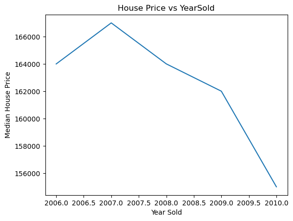

```python
## Lets analyze the Temporal Datetime Variables
## We will check whether there is a relation between year the house is sold and the sales price

dataset_df.groupby('YrSold')['SalePrice'].median().plot()
plt.xlabel('Year Sold')
plt.ylabel('Median House Price')
plt.title("House Price vs YearSold")
plt.show()
```

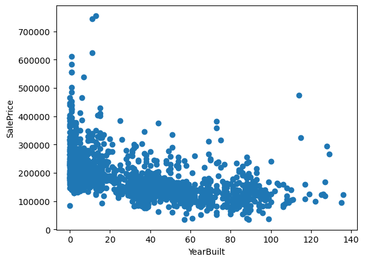

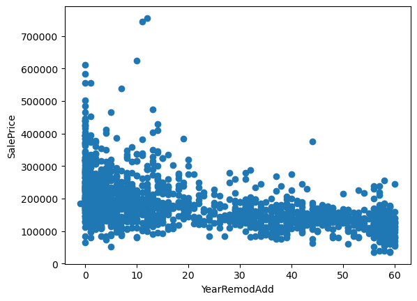

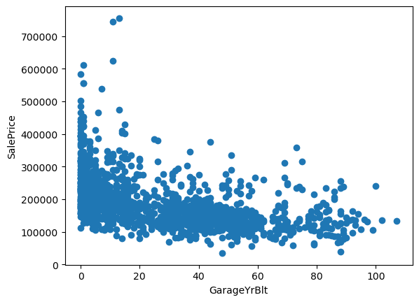

```python
## Here we will compare the difference between All years feature with SalePrice

for feature in year_feature:
    if feature!='YrSold':
        data=dataset_df.copy()
        ## We will capture the difference between year variable and year the house was sold for
        data[feature]=data['YrSold']-data[feature]

        plt.scatter(data[feature],data['SalePrice'])
        plt.xlabel(feature)
        plt.ylabel('SalePrice')
        plt.show()
```

There is a clear indication that as the gap between YearBuilt and YrSold increases, SalePrice tends to decrease. Next, we examine correlations with other variables to identify additional factors influencing SalePrice beyond the year-related features.

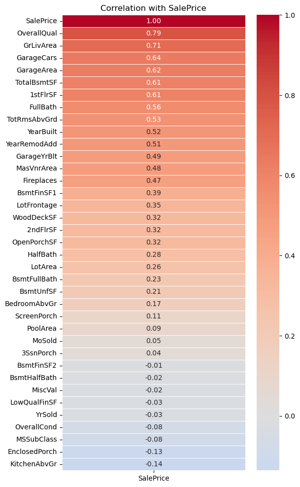

```python
num_df = dataset_df.select_dtypes(include="number")
corr_saleprice = num_df.corr()[["SalePrice"]].sort_values(by="SalePrice", ascending=False)

plt.figure(figsize=(6, 12))
sns.heatmap(corr_saleprice, annot=True, fmt=".2f", cmap="coolwarm", center=0, linewidths=0.5)
plt.title("Correlation with SalePrice")
plt.show()
```

This also give us an idea that living are ,garagecars and areas has impact on the sale

Another way of looking into it with grapfhical view

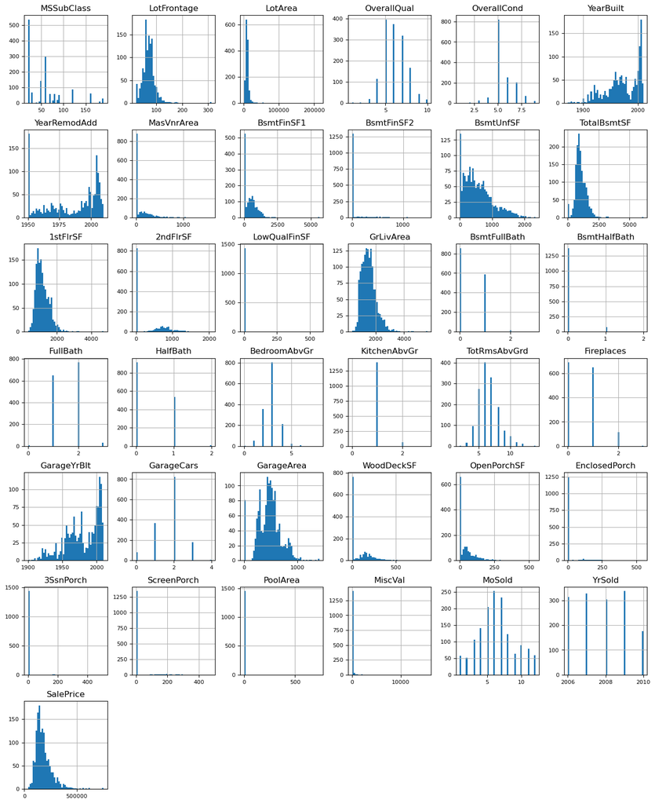

```python
g=df_num.hist(figsize=(16, 20), bins=50, xlabelsize=8, ylabelsize=8);
plt.show()
```

This also give us a picture how year of build ,living area size and garage year built has an impact on the sales price

4 .Engage in feature creation by splitting, merging, or otherwise generating a new predictor.

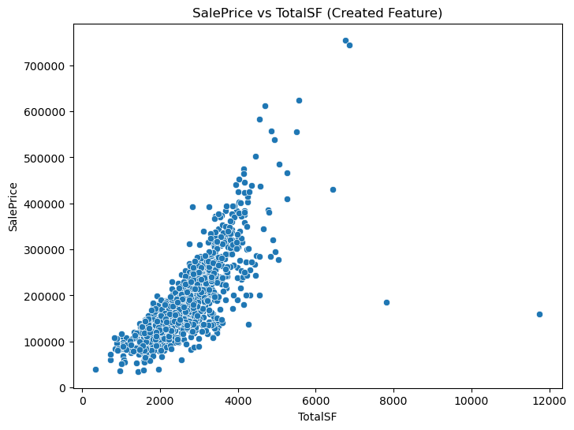

```
Correlation (TotalSF, SalePrice): 0.782
```

```python
dataset_df["TotalSF"] = (
    dataset_df.get("TotalBsmtSF", 0).fillna(0) +
    dataset_df.get("1stFlrSF", 0).fillna(0) +
    dataset_df.get("2ndFlrSF", 0).fillna(0)
)

plt.figure(figsize=(8,6))
sns.scatterplot(x="TotalSF", y="SalePrice", data=dataset_df)
plt.title("SalePrice vs TotalSF (Created Feature)")
plt.show()

print("Correlation (TotalSF, SalePrice):", dataset_df[["TotalSF","SalePrice"]].corr().iloc[0,1].round(3))
```

This scatter plot examines the relationship between the dependent variable SalePrice and the engineered predictor TotalSF.  
TotalSF is a created feature that combines multiple area-related variables (e.g., basement + 1st floor + 2nd floor square footage) to better represent the total usable space of a home.

Key observations:

- The plot shows a clear positive relationship: homes with larger TotalSF generally sell for higher prices.
- The correlation between TotalSF and SalePrice is 0.782, indicating a strong positive linear association. This suggests TotalSF is a strong candidate predictor for SalePrice.
- The spread of SalePrice increases as TotalSF increases, meaning price variability is larger for bigger homes. This pattern suggests heteroscedasticity, where additional factors (e.g., quality, neighborhood, renovations) likely explain more of the price differences among larger properties.

Outliers:

- A few points appear far from the main cluster (very large TotalSF and/or unusually high or low SalePrice).  
  These outliers may represent rare luxury properties, data entry issues, or atypical homes. They should be investigated because they can influence correlation and model fitting.

Conclusion: Overall, TotalSF captures an important structural driver of price and shows a strong relationship with SalePrice, making it a useful engineered feature for downstream modeling.

5. Using the dependent variable, perform both min-max and standard scaling in Python.

```python
from sklearn.preprocessing import MinMaxScaler, StandardScaler

y = dataset_df[["SalePrice"]]  # keep as DataFrame

mm = MinMaxScaler()
ss = StandardScaler()

dataset_df["SalePrice_minmax"] = mm.fit_transform(y)
dataset_df["SalePrice_standard"] = ss.fit_transform(y)

dataset_df[["SalePrice", "SalePrice_minmax", "SalePrice_standard"]].head()
```

|  | SalePrice | SalePrice_minmax | SalePrice_standard |
| --- | --- | --- | --- |
| 0 | 208500 | 0.241078 | 0.347273 |
| 1 | 181500 | 0.203583 | 0.007288 |
| 2 | 223500 | 0.261908 | 0.536154 |
| 3 | 140000 | 0.145952 | -0.515281 |
| 4 | 250000 | 0.298709 | 0.869843 |

```python
print("Original SalePrice:", dataset_df["SalePrice"].mean(), dataset_df["SalePrice"].std())
print("MinMax SalePrice:", dataset_df["SalePrice_minmax"].mean(), dataset_df["SalePrice_minmax"].std())
print("Standard SalePrice:", dataset_df["SalePrice_standard"].mean(), dataset_df["SalePrice_standard"].std())
```

```
Original SalePrice: 180921.19589041095 79442.50288288663
MinMax SalePrice: 0.20277905275713232 0.11032148713079667
Standard SalePrice: 1.3626846987180004e-16 1.0003426417780876
```

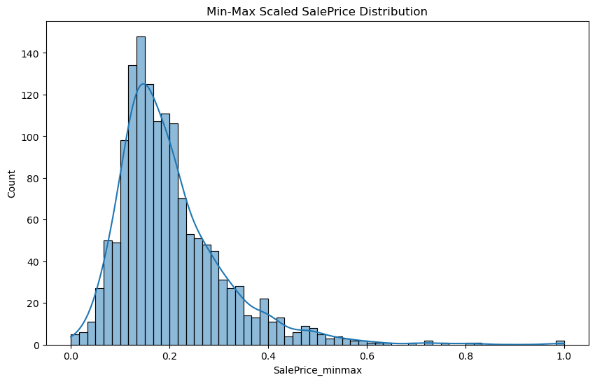

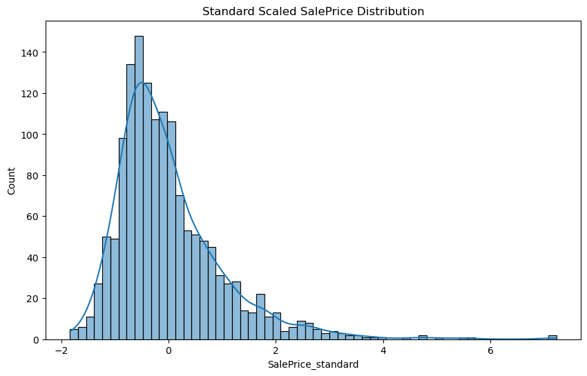

```python
plt.figure(figsize=(10,6))
sns.histplot(dataset_df["SalePrice_minmax"], bins=60, kde=True)
plt.title("Min-Max Scaled SalePrice Distribution")
plt.show()

plt.figure(figsize=(10,6))
sns.histplot(dataset_df["SalePrice_standard"], bins=60, kde=True)
plt.title("Standard Scaled SalePrice Distribution")
plt.show()
```

The two plots show the distribution of SalePrice after applying two common scaling techniques: Min-Max scaling and Standard (z-score) scaling. Scaling does not change the underlying ordering of values; it only changes the numeric range and units so that the target variable is on a consistent scale for modeling.

Min-Max Scaled SalePrice:

- Min-Max scaling rescales SalePrice to the range [0, 1], where 0 corresponds to the minimum SalePrice and 1 corresponds to the maximum SalePrice.
- The shape of the distribution remains right-skewed, with most observations concentrated near the lower end of the range (around 0.1–0.3) and a long tail approaching 1.0.
- This indicates that most homes are priced closer to the lower-to-mid range, while a small number of high-priced properties stretch the upper tail.
- Min-Max scaling is sensitive to extreme values because the minimum and maximum define the full scale, so outliers can compress the majority of values into a narrow band.

Standard Scaled SalePrice:

- Standard scaling converts SalePrice into z-scores by subtracting the mean and dividing by the standard deviation.
- After scaling, the distribution is centered around 0 (the mean), and values represent how many standard deviations a point is from the mean.
- The distribution still shows a strong right tail, with several observations far above the mean (large positive z-scores), confirming the presence of high-price outliers.
- Some values fall below 0 (negative z-scores), representing homes priced below the mean.

Conclusion: Both scaling methods preserve the original right-skewed nature of SalePrice, indicating that scaling alone does not fix skewness. The long right tail suggests that a log transformation (e.g., log1p(SalePrice)) may be helpful if the goal is to make the target distribution closer to normal and reduce the influence of extreme high-priced outliers in downstream modeling.